# Отчёт по модулю 2 курса ‘Stepik Введение в Linux’

Дисциплина: Операционные системы

Мацюк Константин Владимирович

Российский университет дружбы народов

2026

## Содержание (1)

- Цель работы
- Задание
- Знакомство с сервером
- Обмен файлами
- Запуск приложений

## Содержание (2)

- Контроль запускаемых программ
- Многопоточные приложения
- Менеджер терминалов Tmux
- Выводы

# Цель работы

Пройти второй модуль курса «Введение в Linux» на платформе Stepik.

# Задание

Выполнить все задания модуля 2.

# Знакомство с сервером

Удалённый сервер может использоваться для хранения любых данных, выполнения вычислений и организации разного уровня доступа — верны все четыре варианта ответа.

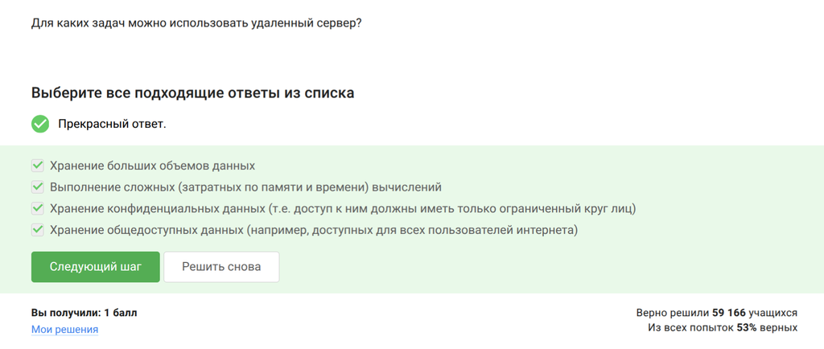

Пример вопроса про удалённый сервер

Открытый ключ (`id_rsa.pub`) не содержит секретной информации, поэтому его можно свободно передавать.

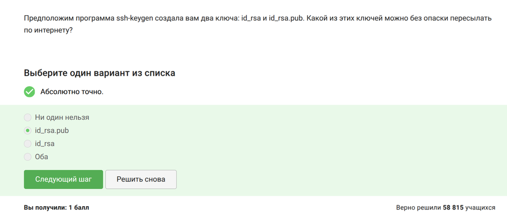

Информация об открытом ключе

# Обмен файлами

Для рекурсивного копирования директорий используется команда `scp -r stepic username@server:~/`.

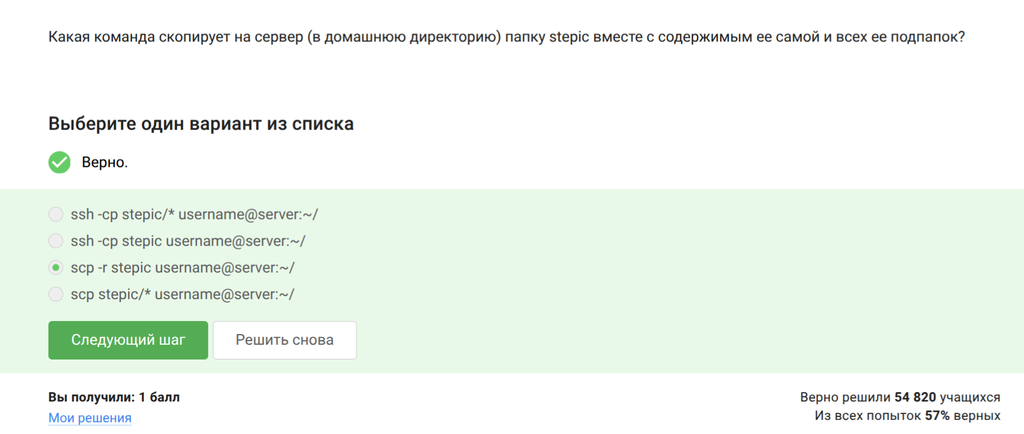

Рекурсивное копирование scp

Перед установкой программы необходимо выполнить `sudo apt-get update`, чтобы обновить список пакетов.

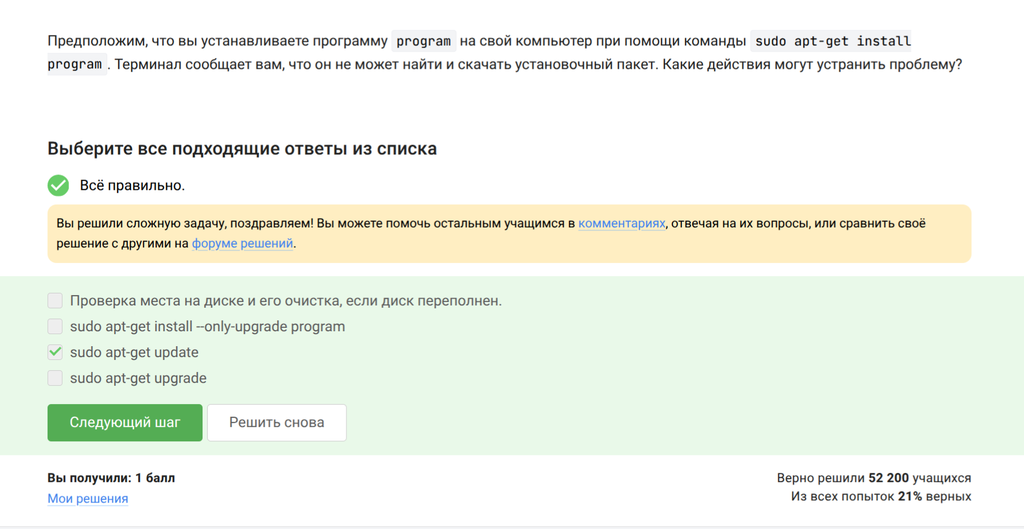

Обновление списка пакетов

Программа Filezilla — это FTP-менеджер, позволяющий просматривать содержимое локального и удалённого компьютера, а также копировать файлы.

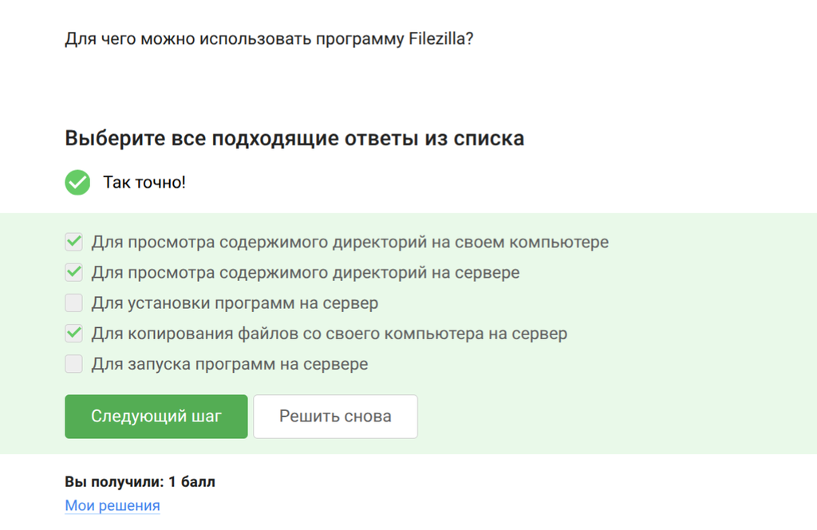

Filezilla

# Запуск приложений

Если программа не запускается, можно проверить другую версию или настроить сервер для вывода графики.

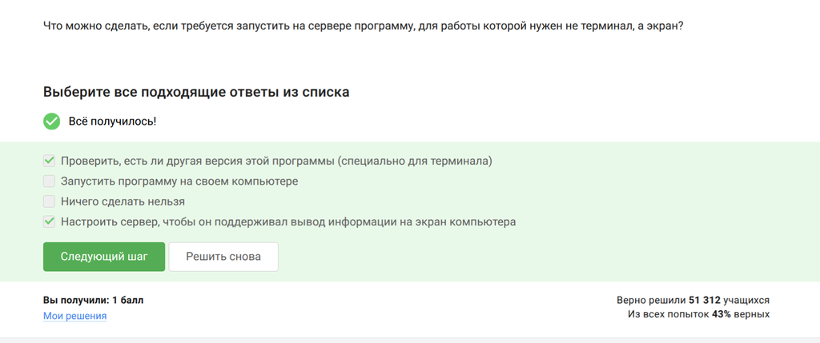

Ошибка запуска приложения

Справка по программе вызывается командами: `man program`, `help program`, `program --help`.

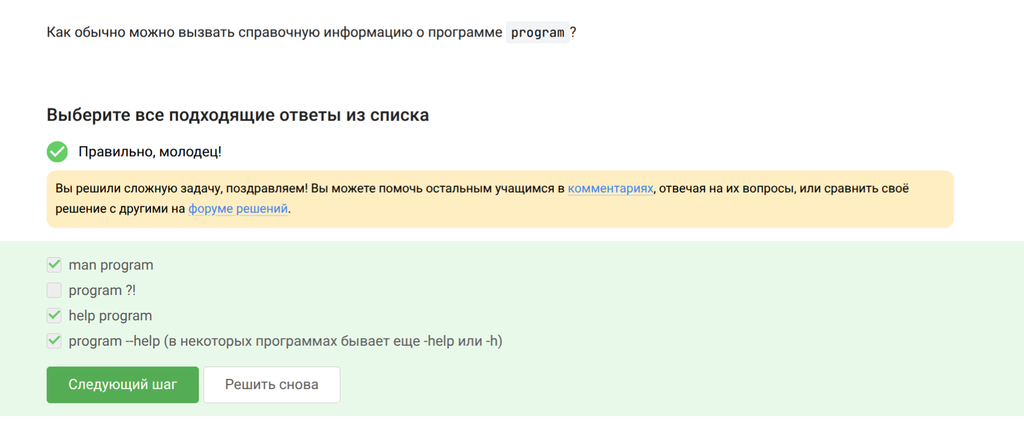

Способы вызова справки

FastQC принимает на вход форматы **fastq, bam, sam**.

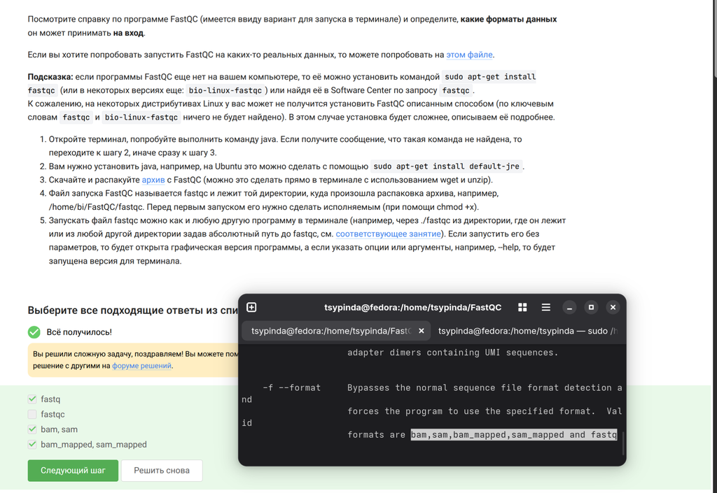

Форматы для FastQC

Для множественного выравнивания последовательностей в ClustalW используется команда `clustalw test.fasta -align`.

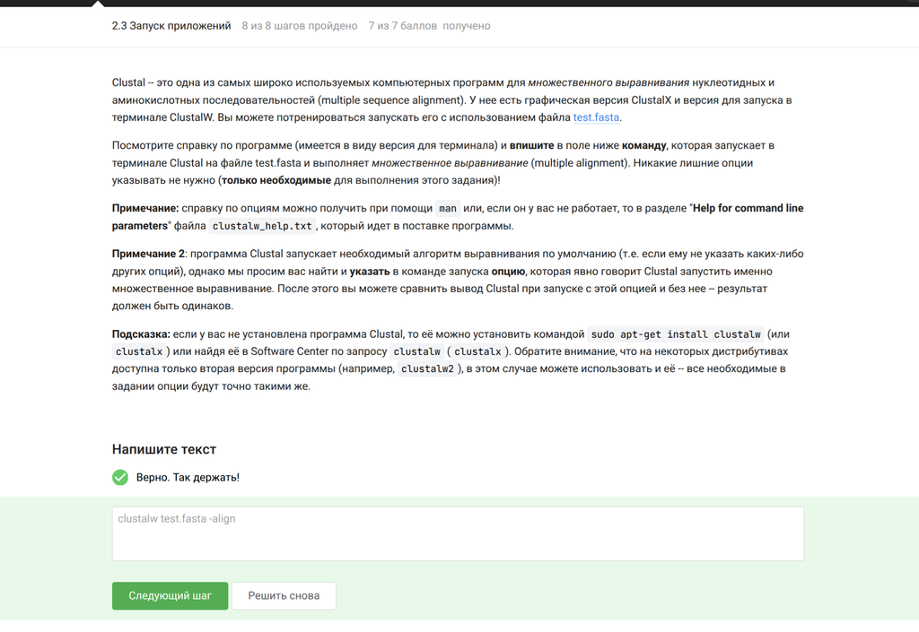

Команда для ClustalW

# Контроль запускаемых программ

Программа, завершённая через `Ctrl+C`, не отображается в списке `jobs`. Приостановленная программа остаётся в списке.

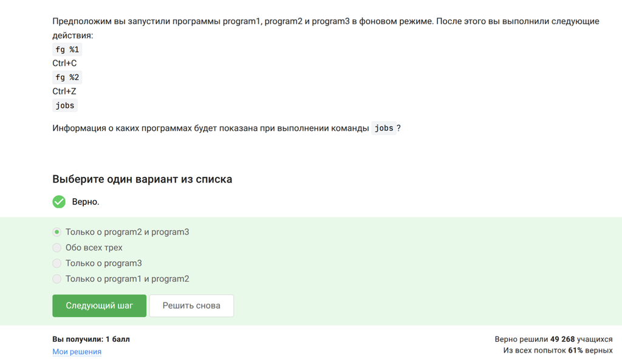

Список задач jobs

Команды `ps` и `top` показывают одни и те же процессы, тогда как `jobs` показывает только фоновые задачи текущей оболочки.

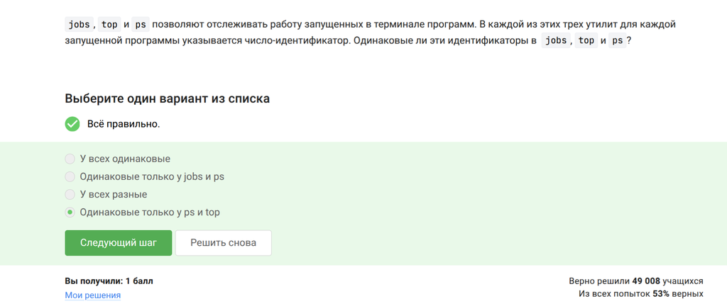

Сравнение ps, top и jobs

Сигнал `SIGKILL (9)` принудительно завершает процесс мгновенно: `kill -9`.

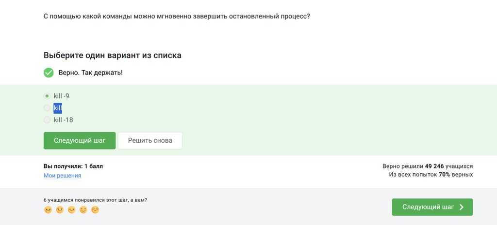

Принудительное завершение процесса

`kill` без опции отправляет сигнал `SIGTERM`, который обрабатывается после возобновления работы процесса.

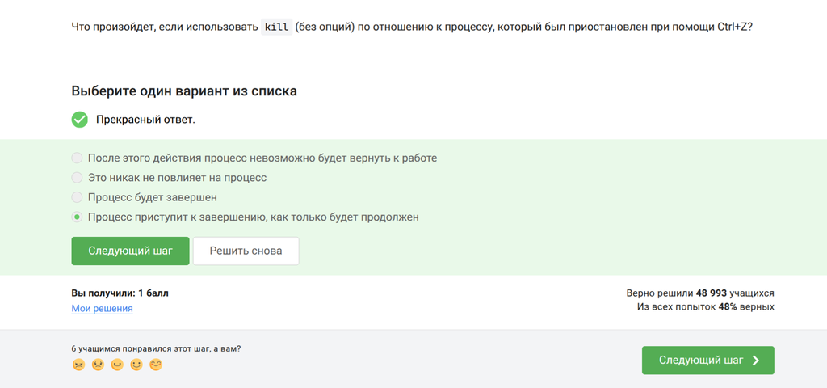

Отправка SIGTERM

# Многопоточные приложения

Остановленное приложение не использует процессорное время (0% CPU).

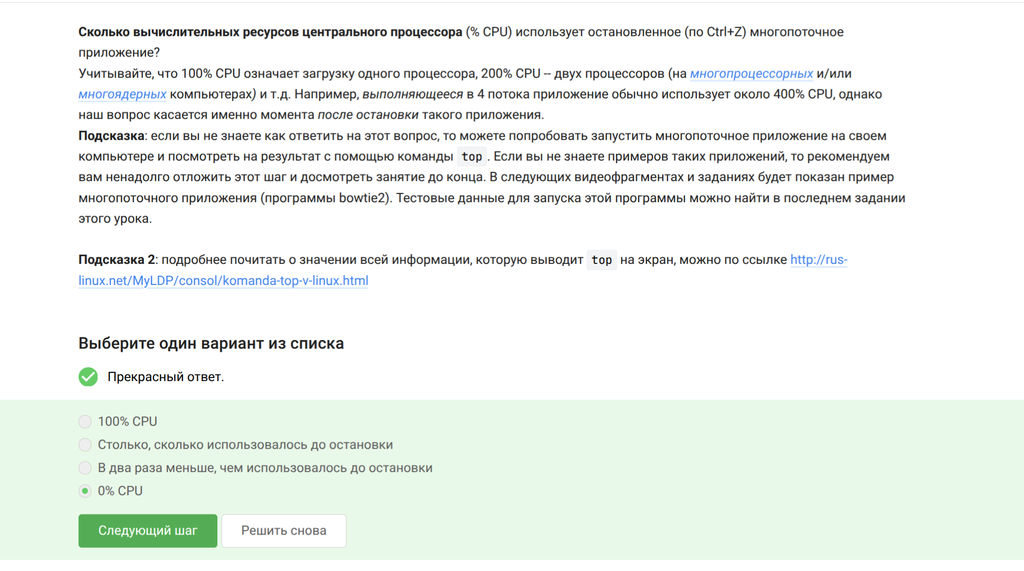

Процессорное время остановленного приложения

Столько, сколько оно потребляло в момент остановки, потому что остановка не освобождает память, она лишь приостанавливает выполнение.

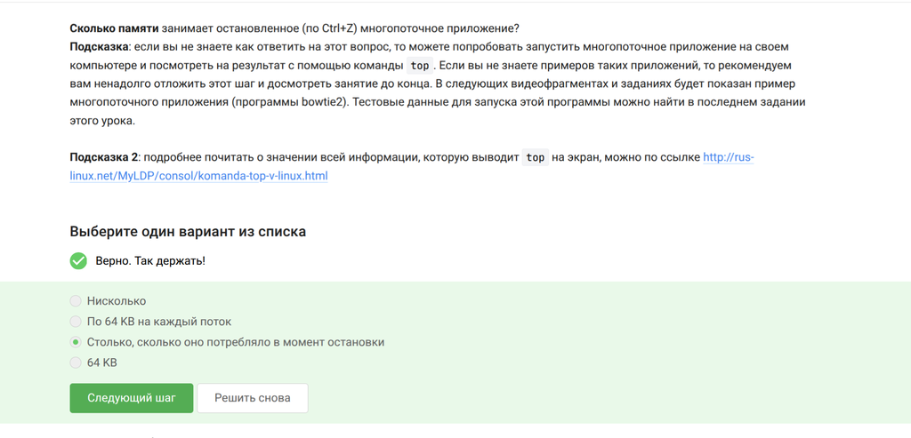

Использование памяти после остановки приложения

Никак, многопоточное приложение управляется как единый процесс, и завершить один поток без остановки всего процесса невозможно.

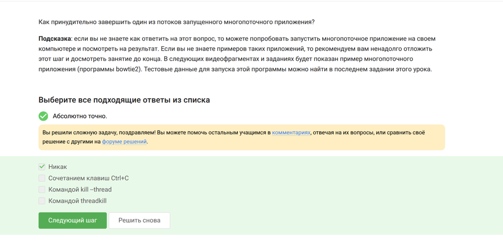

Невозможность завершения отдельного потока

Этап выравнивания можно распараллелить, а этап построения индекса выполняется в одном потоке.

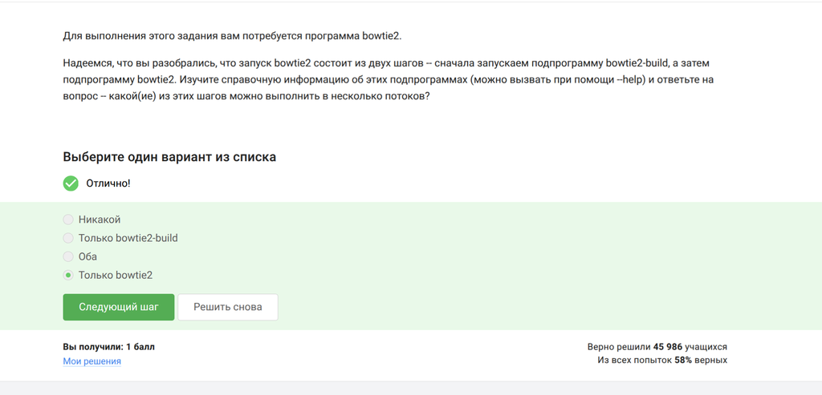

Распараллеливание этапов bowtie2

Программа bowtie2 выводит статистику (количество прочитанных ридов и процент выравнивания) через `stderr`.

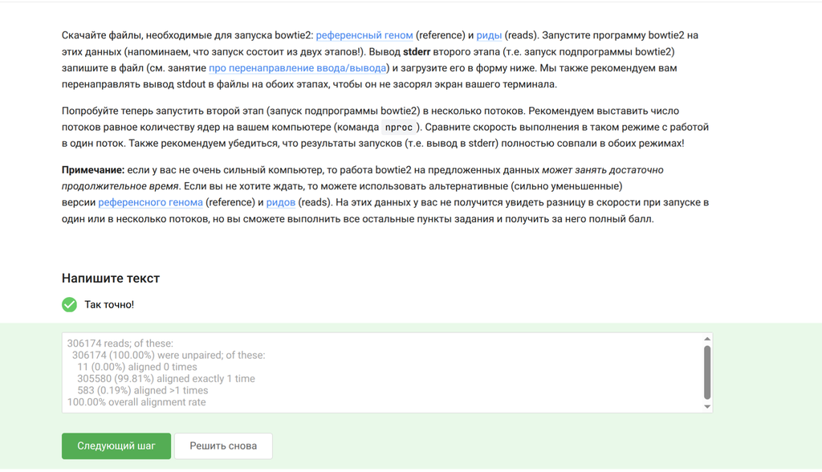

Вывод статистики bowtie2